# Peer-graded Assignment: Prediction Assignment Writeup

Yanyuan Zhu

9/4/2020

### 1. Introduction

The goal of your project is to predict the manner in which they did the exercise. This is the “classe” variable in the training set. You may use any of the other variables to predict with. You should create a report describing how you built your model, how you used cross validation, what you think the expected out of sample error is, and why you made the choices you did. You will also use your prediction model to predict 20 different test cases.

### 2. Preprocessing

```r
# set working directory
setwd("/home/yanyuan/Soft/Rtest/datasciencecoursera/08_Practical_Machine_Learning/")

# load the requied packages
library(caret)
library(rattle)
# Read and pre-process datasets
# download the related data before run the following commands
training <- read.csv("./data/pml-training.csv", na.strings = c("NA", ""))
testing <- read.csv("./data/pml-testing.csv", na.strings = c("NA", ""))

## EDA
dim(training); dim(testing)
```

```
## [1] 19622   160
```

```
## [1]  20 160
```

There are 19622 observations in training set, 20 in trainingset. In both sets, there are 160 variables to be analyzed, in which `classe` is the outcome.

```r
unique(training$classe)
```

```
## [1] "A" "B" "C" "D" "E"
```

5 fashions are included in the `classe` variable - `Class A`: exactly according to the specification - `Class B`: throwing the elbows to the front - `Class C`: lifting the dumbbell only halfway - `Class D`: lowering the dumbbell only halfway - `Class E`:throwing the hips to the front

Class A corresponds to the specified execution of the exercise, while the other 4 classes correspond to common mistakes.

```r
# str(training)
# head(training)
head(training)
```

```
##   X user_name raw_timestamp_part_1 raw_timestamp_part_2   cvtd_timestamp
## 1 1  carlitos           1323084231               788290 05/12/2011 11:23
## 2 2  carlitos           1323084231               808298 05/12/2011 11:23
## 3 3  carlitos           1323084231               820366 05/12/2011 11:23
## 4 4  carlitos           1323084232               120339 05/12/2011 11:23
## 5 5  carlitos           1323084232               196328 05/12/2011 11:23
## 6 6  carlitos           1323084232               304277 05/12/2011 11:23
##   new_window num_window roll_belt pitch_belt yaw_belt total_accel_belt
## 1         no         11      1.41       8.07    -94.4                3
## 2         no         11      1.41       8.07    -94.4                3
## 3         no         11      1.42       8.07    -94.4                3
## 4         no         12      1.48       8.05    -94.4                3
## 5         no         12      1.48       8.07    -94.4                3
## 6         no         12      1.45       8.06    -94.4                3
##   kurtosis_roll_belt kurtosis_picth_belt kurtosis_yaw_belt skewness_roll_belt
```

[output cut: 251 more lines]

Remove the first 7 columns which are irrelevant for analysis

```r
training <- training[,-c(1:7)]
testing <- testing[, -c(1:7)]
```

```r
head(training)
```

```
##   roll_belt pitch_belt yaw_belt total_accel_belt kurtosis_roll_belt
## 1      1.41       8.07    -94.4                3               <NA>
## 2      1.41       8.07    -94.4                3               <NA>
## 3      1.42       8.07    -94.4                3               <NA>
## 4      1.48       8.05    -94.4                3               <NA>
## 5      1.48       8.07    -94.4                3               <NA>
## 6      1.45       8.06    -94.4                3               <NA>
##   kurtosis_picth_belt kurtosis_yaw_belt skewness_roll_belt skewness_roll_belt.1
## 1                <NA>              <NA>               <NA>                 <NA>
## 2                <NA>              <NA>               <NA>                 <NA>
## 3                <NA>              <NA>               <NA>                 <NA>
## 4                <NA>              <NA>               <NA>                 <NA>
## 5                <NA>              <NA>               <NA>                 <NA>
## 6                <NA>              <NA>               <NA>                 <NA>
##   skewness_yaw_belt max_roll_belt max_picth_belt max_yaw_belt min_roll_belt
```

[output cut: 237 more lines]

There are so many items with NA values, which are supposed to be deleted

```r
name_list <- names(training)[!colSums(is.na(training))>0]
# name_list
training <- training[,name_list]
dim(training)
```

```
## [1] 19622    53
```

With train-test-split already finished, we furthermore split training set into training and cross validation sets accordingly

```r
set.seed(7826)
inTrain <- createDataPartition(y = training$classe
                              , p = 0.7
                              , list = FALSE
                              )
validation <- training[-inTrain, ]
training <- training[inTrain, ]
```

```r
dim(training); dim(validation); dim(testing)
```

```
## [1] 13737    53
```

```
## [1] 5885   53
```

```
## [1]  20 153
```

```r
# dim(training)[1] + dim(validation)[1] + dim(testing)[1] == 19642 # TRUE
```

Change classe type from chr to factor

```r
# str(validation$classe)
training$classe <- factor(training$classe)
validation$classe <- factor(validation$classe)
# testing$classe <- factor(testing$classe)
```

## 3. Modelling

We set up 2 modelling algorithms: classification trees, and random forests, to predict the outcome

### 3.1 Classification Trees

Set $k=5$ for k-fold cors validation

```r
modFit_rpart <- train(classe ~.
                     , data = training
                     , method = 'rpart'
                     , trControl = trainControl(method = "cv", number = 5)
                      )
modFit_rpart
```

```
## CART
##
## 13737 samples
##    52 predictor
##     5 classes: 'A', 'B', 'C', 'D', 'E'
##
## No pre-processing
## Resampling: Cross-Validated (5 fold)
## Summary of sample sizes: 10990, 10990, 10990, 10989, 10989
## Resampling results across tuning parameters:
##
##   cp          Accuracy   Kappa
##   0.03102431  0.5260239  0.38037552
##   0.05953955  0.3935299  0.16981833
##   0.11585800  0.3168074  0.04946018
##
## Accuracy was used to select the optimal model using the largest value.
## The final value used for the model was cp = 0.03102431.
```

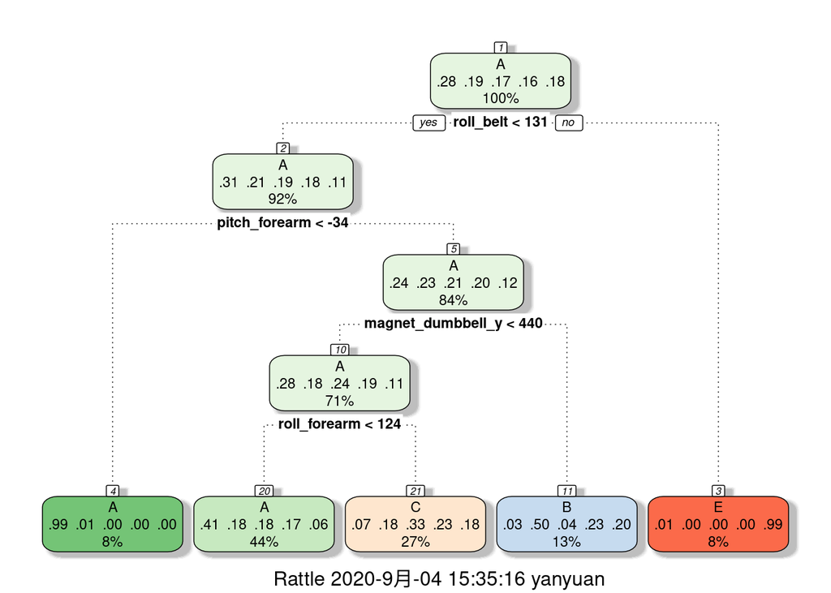

```r
fancyRpartPlot(modFit_rpart$finalModel)
```

Predict outcomes using validation set

```r
pred_rpart <- predict(modFit_rpart, validation)
conf_rpart <- confusionMatrix(pred_rpart, validation$classe)
conf_rpart
```

```
## Confusion Matrix and Statistics
##
##           Reference
## Prediction    A    B    C    D    E
##          A 1510  464  467  432  164
##          B   27  410   37  163  144
##          C  134  265  522  369  293
##          D    0    0    0    0    0
##          E    3    0    0    0  481
##
## Overall Statistics
##
##                Accuracy : 0.4967
##                  95% CI : (0.4838, 0.5095)
##     No Information Rate : 0.2845
##     P-Value [Acc > NIR] : < 2.2e-16
##
##                   Kappa : 0.3425
##
##  Mcnemar's Test P-Value : NA
##
## Statistics by Class:
##
##                      Class: A Class: B Class: C Class: D Class: E
## Sensitivity            0.9020  0.35996   0.5088   0.0000  0.44455
## Specificity            0.6374  0.92183   0.7816   1.0000  0.99938
## Pos Pred Value         0.4972  0.52497   0.3298      NaN  0.99380
## Neg Pred Value         0.9424  0.85717   0.8828   0.8362  0.88872
## Prevalence             0.2845  0.19354   0.1743   0.1638  0.18386
## Detection Rate         0.2566  0.06967   0.0887   0.0000  0.08173
## Detection Prevalence   0.5161  0.13271   0.2690   0.0000  0.08224
## Balanced Accuracy      0.7697  0.64090   0.6452   0.5000  0.72196
```

In which we can see the total accuracy of classification trees algorithm is:

```r
conf_rpart$overall[1]
```

```
##  Accuracy
## 0.4966865
```

which is not quite good, indicating the classification trees is nog a good model to predict outcome `classe`.

### 3.2 Random Forest

We try alternative algorithm, the random forest

```r
# caution: it takes about 7 minutes in my PC, be patient
modFit_rf <- train(classe ~.
                   , data = training
                   , method = 'rf'
                   , trControl = trainControl(method = 'cv', number = 5)
)
modFit_rf
```

```
## Random Forest
##
## 13737 samples
##    52 predictor
##     5 classes: 'A', 'B', 'C', 'D', 'E'
##
## No pre-processing
## Resampling: Cross-Validated (5 fold)
## Summary of sample sizes: 10991, 10990, 10990, 10988, 10989
## Resampling results across tuning parameters:
##
##   mtry  Accuracy   Kappa
##    2    0.9912647  0.9889487
##   27    0.9920651  0.9899622
##   52    0.9839845  0.9797391
##
## Accuracy was used to select the optimal model using the largest value.
## The final value used for the model was mtry = 27.
```

Predict outcomes using validation set

```r
pred_rf <- predict(modFit_rf, validation)
conf_rf <- confusionMatrix(pred_rf, validation$classe)
conf_rf
```

```
## Confusion Matrix and Statistics
##
##           Reference
## Prediction    A    B    C    D    E
##          A 1671    4    0    0    0
##          B    2 1134    8    0    1
##          C    0    1 1013   16    1
##          D    0    0    5  947    9
##          E    1    0    0    1 1071
##
## Overall Statistics
##
##                Accuracy : 0.9917
##                  95% CI : (0.989, 0.9938)
##     No Information Rate : 0.2845
##     P-Value [Acc > NIR] : < 2.2e-16
##
##                   Kappa : 0.9895
##
##  Mcnemar's Test P-Value : NA
##
## Statistics by Class:
##
##                      Class: A Class: B Class: C Class: D Class: E
## Sensitivity            0.9982   0.9956   0.9873   0.9824   0.9898
## Specificity            0.9991   0.9977   0.9963   0.9972   0.9996
## Pos Pred Value         0.9976   0.9904   0.9825   0.9854   0.9981
## Neg Pred Value         0.9993   0.9989   0.9973   0.9965   0.9977
## Prevalence             0.2845   0.1935   0.1743   0.1638   0.1839
## Detection Rate         0.2839   0.1927   0.1721   0.1609   0.1820
## Detection Prevalence   0.2846   0.1946   0.1752   0.1633   0.1823
## Balanced Accuracy      0.9986   0.9966   0.9918   0.9898   0.9947
```

In which we can see the total accuracy of random forest algorithm is:

```r
conf_rf$overall[1]
```

```
##  Accuracy
## 0.9916737
```

which indicates that random forest is a good model to predict outcome `classe`

### 4. Prediction on Testing set

```r
predict(modFit_rf, testing)
```

```
##  [1] B A B A A E D B A A B C B A E E A B B B
## Levels: A B C D E
```